# Project PredictionAssignment

B. van Bekkum

oct 12 2018

# Introduction

Using devices such as Jawbone Up, Nike FuelBand, and Fitbit it is now possible to collect a large amount of data about personal activity relatively inexpensively. These type of devices are part of the quantified self movement - a group of enthusiasts who take measurements about themselves regularly to improve their health, to find patterns in their behavior, or because they are tech geeks. One thing that people regularly do is quantify how much of a particular activity they do, but they rarely quantify how well they do it. In this project, your goal will be to use data from accelerometers on the belt, forearm, arm, and dumbell of 6 participants. They were asked to perform barbell lifts correctly and incorrectly in 5 different ways. More information is available from the website here: http://web.archive.org/web/20161224072740/http:/groupware.les.inf.puc-rio.br/har (see the section on the Weight Lifting Exercise Dataset).

# Preparation

## Step 1: load and clean the data

```r
TrainRaw <- read.csv('C:/Users/bart/Dropbox/Coursera/8_ML/pml-training.csv')
TestRaw  <- read.csv('C:/Users/bart/Dropbox/Coursera/8_ML/pml-testing.csv')
dim(TrainRaw)
```

```
## [1] 19622   160
```

In the documentation the explanation of the column classes is found:

- exactly according to the specification (Class A)
- throwing the elbows to the front (Class B),
- lifting the dumbbell only halfway (Class C),
- lowering the dumbbell only halfway (Class D) and
- throwing the hips to the front (Class E).

The datasets are cleaned because the raw data contains a lot of calculated columns that are mostly all NA. The relevant columns are subsetted:

```r
y <- names(c(TrainRaw[,grepl('^roll_',  names(TrainRaw))],
             TrainRaw[,grepl('^pitch_', names(TrainRaw))],
             TrainRaw[,grepl('^yaw_',   names(TrainRaw))],
             TrainRaw[,grepl('^total_', names(TrainRaw))],
             TrainRaw[,grepl('^gyros_', names(TrainRaw))],
             TrainRaw[,grepl('^accel_', names(TrainRaw))],
             TrainRaw[,grepl('^magnet_',names(TrainRaw))])
             )
DFTrain        <- TrainRaw[,y]
DFTrain$classe <- TrainRaw$classe
DFTest         <- TestRaw[,y]
DFTest$classe  <- TestRaw$classe
dim(DFTrain); dim(DFTest)
```

```
## [1] 19622    53
```

```
## [1] 20 52
```

## Step 2: create a trainingset and a testset

The original trainingset is splitted in a training and a testset (the original testset is set aside for the final prediction):

```r
set.seed(1213)
inTrain <- createDataPartition(y=DFTrain$classe, p=0.75, list=FALSE)
training <- DFTrain[inTrain,]
testing <- DFTrain[-inTrain,]
dim(training); dim(testing)
```

```
## [1] 14718    53
```

```
## [1] 4904   53
```

# Build models

First I build a simple tree-model and try to enhance it with cross-validation. Then I try a more complex model.

## Model 1: a basic tree-model without cross validation

```r
modfitRP <- train(classe~., data=training, method="rpart")
modfitRP$finalModel
```

```
## n= 14718
##
## node), split, n, loss, yval, (yprob)
##       * denotes terminal node
##
##  1) root 14718 10533 A (0.28 0.19 0.17 0.16 0.18)
##    2) roll_belt< 130.5 13485  9311 A (0.31 0.21 0.19 0.18 0.11)
##      4) pitch_forearm< -33.95 1158     5 A (1 0.0043 0 0 0) *
##      5) pitch_forearm>=-33.95 12327  9306 A (0.25 0.23 0.21 0.2 0.12)
##       10) magnet_dumbbell_y< 439.5 10453  7497 A (0.28 0.18 0.24 0.19 0.11)
##         20) roll_forearm< 123.5 6500  3848 A (0.41 0.18 0.18 0.17 0.059) *
##         21) roll_forearm>=123.5 3953  2664 C (0.077 0.18 0.33 0.23 0.19) *
##       11) magnet_dumbbell_y>=439.5 1874   914 B (0.035 0.51 0.043 0.22 0.19) *
##    3) roll_belt>=130.5 1233    11 E (0.0089 0 0 0 0.99) *
```

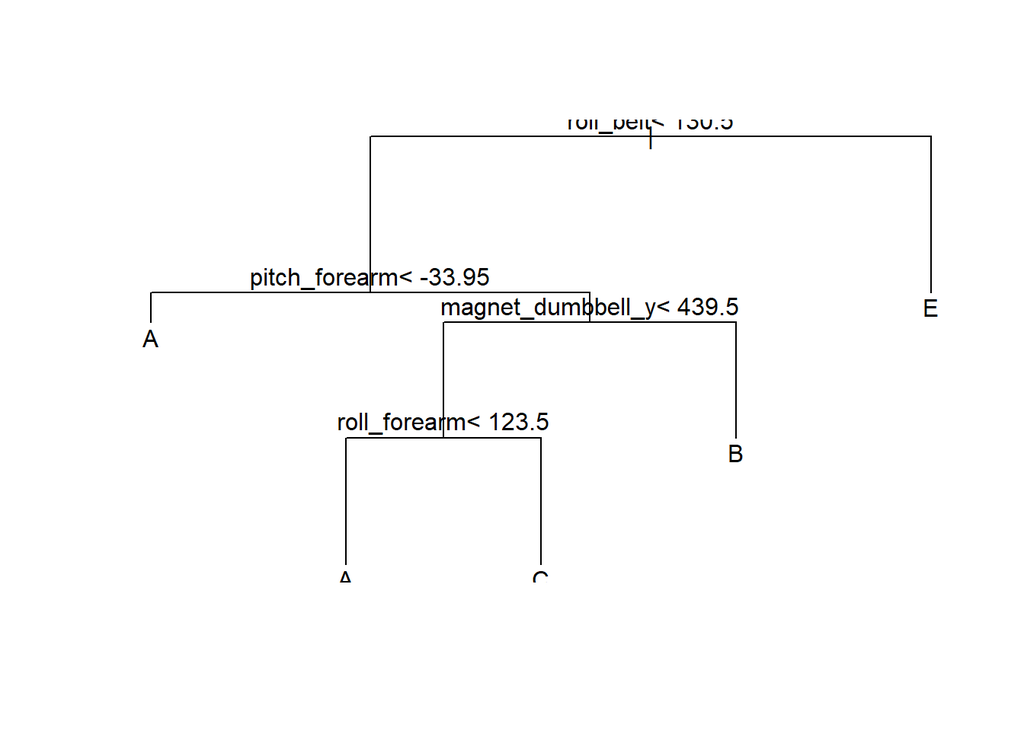

```r
plot(modfitRP$finalModel)
text(modfitRP$finalModel)
```

## Model 2: add cross validation to the basic tree-model

```r
controlRCV  <- trainControl(method="repeatedcv", number=10, repeats = 3)
modfitRPRCV <- train(classe~., data=training, method="rpart", trControl=controlRCV, tuneLength = 15)
modfitRPRCV$finalModel
```

```
## n= 14718
##
## node), split, n, loss, yval, (yprob)
##       * denotes terminal node
##
##     1) root 14718 10533 A (0.28 0.19 0.17 0.16 0.18)
##       2) roll_belt< 130.5 13485  9311 A (0.31 0.21 0.19 0.18 0.11)
##         4) pitch_forearm< -33.95 1158     5 A (1 0.0043 0 0 0) *
##         5) pitch_forearm>=-33.95 12327  9306 A (0.25 0.23 0.21 0.2 0.12)
##          10) magnet_dumbbell_y< 439.5 10453  7497 A (0.28 0.18 0.24 0.19 0.11)
##            20) roll_forearm< 123.5 6500  3848 A (0.41 0.18 0.18 0.17 0.059)
##              40) magnet_dumbbell_z< -27.5 2180   709 A (0.67 0.21 0.014 0.072 0.029)
##                80) roll_forearm>=-136.5 1834   402 A (0.78 0.17 0.014 0.025 0.006) *
##                81) roll_forearm< -136.5 346   207 B (0.11 0.4 0.014 0.32 0.15) *
##              41) magnet_dumbbell_z>=-27.5 4320  3139 A (0.27 0.17 0.27 0.22 0.075)
##                82) yaw_belt>=169.5 522    62 A (0.88 0.048 0 0.069 0.0019) *
##                83) yaw_belt< 169.5 3798  2631 C (0.19 0.18 0.31 0.24 0.085)
##                 166) accel_dumbbell_y>=-40.5 3280  2400 D (0.22 0.2 0.22 0.27 0.091)
##                   332) pitch_belt< -42.95 402    80 B (0.02 0.8 0.11 0.047 0.025) *
##                   333) pitch_belt>=-42.95 2878  2017 D (0.25 0.12 0.23 0.3 0.1)
##                     666) roll_belt>=125.5 668   268 C (0.37 0.021 0.6 0.009 0.0015)
##                      1332) magnet_belt_z< -324.5 209     3 A (0.99 0 0.0096 0 0.0048) *
##                      1333) magnet_belt_z>=-324.5 459    61 C (0.089 0.031 0.87 0.013 0) *
##                     667) roll_belt< 125.5 2210  1355 D (0.21 0.15 0.12 0.39 0.13)
##                      1334) pitch_belt>=1.035 1397  1062 A (0.24 0.22 0.13 0.22 0.18)
##                        2668) accel_dumbbell_z< 27.5 897   578 A (0.36 0.13 0.2 0.27 0.036)
##                          5336) yaw_forearm>=-94.65 651   332 A (0.49 0.17 0.22 0.078 0.04)
##                           10672) magnet_forearm_z>=-125.5 432   120 A (0.72 0.12 0.019 0.1 0.039) *
##                           10673) magnet_forearm_z< -125.5 219    84 C (0.032 0.28 0.62 0.032 0.041) *
##                          5337) yaw_forearm< -94.65 246    51 D (0 0.028 0.15 0.79 0.024) *
##                        2669) accel_dumbbell_z>=27.5 500   276 E (0.032 0.37 0.01 0.14 0.45)
##                          5338) roll_dumbbell< 39.4826 181    37 B (0.028 0.8 0.028 0.055 0.094) *
##                          5339) roll_dumbbell>=39.4826 319   112 E (0.034 0.13 0 0.18 0.65) *
##                      1335) pitch_belt< 1.035 813   272 D (0.16 0.032 0.11 0.67 0.037)
##                        2670) yaw_arm< -96.65 118     0 A (1 0 0 0 0) *
##                        2671) yaw_arm>=-96.65 695   154 D (0.014 0.037 0.13 0.78 0.043) *
##                 167) accel_dumbbell_y< -40.5 518    68 C (0.0058 0.046 0.87 0.031 0.048) *
##            21) roll_forearm>=123.5 3953  2664 C (0.077 0.18 0.33 0.23 0.19)
##              42) magnet_dumbbell_y< 292.5 2316  1209 C (0.093 0.13 0.48 0.15 0.15)
##                84) magnet_forearm_z< -251 188    36 A (0.81 0.069 0 0.048 0.074) *
##                85) magnet_forearm_z>=-251 2128  1021 C (0.03 0.13 0.52 0.16 0.16)
##                 170) pitch_belt>=26.15 141    28 B (0.071 0.8 0.035 0 0.092) *
##                 171) pitch_belt< 26.15 1987   885 C (0.027 0.087 0.55 0.17 0.16) *
##              43) magnet_dumbbell_y>=292.5 1637  1074 D (0.054 0.25 0.11 0.34 0.24)
##                86) accel_forearm_x>=-101.5 1052   702 E (0.047 0.32 0.16 0.15 0.33)
##                 172) magnet_arm_y>=188 428   192 B (0.0093 0.55 0.24 0.098 0.1) *
##                 173) magnet_arm_y< 188 624   318 E (0.072 0.16 0.1 0.18 0.49) *
##                87) accel_forearm_x< -101.5 585   176 D (0.067 0.13 0.027 0.7 0.077) *
##          11) magnet_dumbbell_y>=439.5 1874   914 B (0.035 0.51 0.043 0.22 0.19)
##            22) total_accel_dumbbell>=5.5 1340   466 B (0.049 0.65 0.059 0.022 0.22)
##              44) roll_belt>=-0.58 1131   257 B (0.057 0.77 0.07 0.027 0.073) *
##              45) roll_belt< -0.58 209     0 E (0 0 0 0 1) *
##            23) total_accel_dumbbell< 5.5 534   145 D (0 0.16 0.0037 0.73 0.11)
##              46) yaw_belt< -2.825 79     0 B (0 1 0 0 0) *
##              47) yaw_belt>=-2.825 455    66 D (0 0.015 0.0044 0.85 0.13) *
##       3) roll_belt>=130.5 1233    11 E (0.0089 0 0 0 0.99) *
```

[figure not shown]

```r
fancyRpartPlot(modfitRPRCV$finalModel, cex=0.2, main = "Plot Rpart with cross-validation")
```

## Model 3: a tree-model with bagging and cross-validation

```r
controlTB  <- trainControl(method="repeatedcv", number=10, repeats = 3)
modfitTB   <- train(classe~., data=training, method="treebag", trControl=controlTB)
modfitTB
```

```
## Bagged CART
##
## 14718 samples
##    52 predictor
##     5 classes: 'A', 'B', 'C', 'D', 'E'
##
## No pre-processing
## Resampling: Cross-Validated (10 fold, repeated 3 times)
## Summary of sample sizes: 13246, 13246, 13246, 13247, 13246, 13244, ...
## Resampling results:
##
##   Accuracy   Kappa
##   0.9856409  0.9818364
```

# Check performance of models

## Model 1: accuracy of basic tree-model without cross-validation

```r
predictionRP <- predict(modfitRP, testing)
confmatrRP <- confusionMatrix(predictionRP, testing$classe)
confmatrRP
```

```
## Confusion Matrix and Statistics
##
##           Reference
## Prediction    A    B    C    D    E
##          A 1275  400  390  360  138
##          B   16  326   27  149  137
##          C  101  223  438  295  217
##          D    0    0    0    0    0
##          E    3    0    0    0  409
##
## Overall Statistics
##
##                Accuracy : 0.4992
##                  95% CI : (0.4851, 0.5133)
##     No Information Rate : 0.2845
##     P-Value [Acc > NIR] : < 2.2e-16
##
##                   Kappa : 0.3451
##  Mcnemar's Test P-Value : NA
##
## Statistics by Class:
##
##                      Class: A Class: B Class: C Class: D Class: E
## Sensitivity            0.9140  0.34352  0.51228   0.0000  0.45394
## Specificity            0.6329  0.91681  0.79353   1.0000  0.99925
## Pos Pred Value         0.4975  0.49771  0.34380      NaN  0.99272
## Neg Pred Value         0.9487  0.85338  0.88512   0.8361  0.89047
## Prevalence             0.2845  0.19352  0.17435   0.1639  0.18373
## Detection Rate         0.2600  0.06648  0.08931   0.0000  0.08340
## Detection Prevalence   0.5226  0.13356  0.25979   0.0000  0.08401
## Balanced Accuracy      0.7735  0.63017  0.65290   0.5000  0.72660
```

The accuracy of the basic treemodel is very low: 0.4991843

## Model 2: accuracy basic tree-model with cross-validation

```r
predictionRPRCV <- predict(modfitRPRCV, testing)
confmatrRPRCV <- confusionMatrix(predictionRPRCV, testing$classe)
confmatrRPRCV
```

```
## Confusion Matrix and Statistics
##
##           Reference
## Prediction    A    B    C    D    E
##          A 1266  147   11   42   17
##          B   51  637   66   77  107
##          C   40  102  708  130   95
##          D   14   31   47  509   46
##          E   24   32   23   46  636
##
## Overall Statistics
##
##                Accuracy : 0.7659
##                  95% CI : (0.7538, 0.7777)
##     No Information Rate : 0.2845
##     P-Value [Acc > NIR] : < 2.2e-16
##
##                   Kappa : 0.7032
##  Mcnemar's Test P-Value : < 2.2e-16
##
## Statistics by Class:
##
##                      Class: A Class: B Class: C Class: D Class: E
## Sensitivity            0.9075   0.6712   0.8281   0.6331   0.7059
## Specificity            0.9382   0.9239   0.9094   0.9663   0.9688
## Pos Pred Value         0.8537   0.6791   0.6586   0.7867   0.8357
## Neg Pred Value         0.9623   0.9213   0.9616   0.9307   0.9360
## Prevalence             0.2845   0.1935   0.1743   0.1639   0.1837
## Detection Rate         0.2582   0.1299   0.1444   0.1038   0.1297
## Detection Prevalence   0.3024   0.1913   0.2192   0.1319   0.1552
## Balanced Accuracy      0.9228   0.7976   0.8687   0.7997   0.8373
```

The accuracy of the basic tree-model has been improved with the cross-validation: 0.7659054

## Model 3: accuracy of the treebag model with cross-validation

```r
predictionTB <- predict(modfitTB, testing)
confmatrTB <- confusionMatrix(predictionTB, testing$classe)
confmatrTB
```

```
## Confusion Matrix and Statistics
##
##           Reference
## Prediction    A    B    C    D    E
##          A 1391   16    0    0    0
##          B    1  927    3    1    3
##          C    3    6  849   15    2
##          D    0    0    3  786    0
##          E    0    0    0    2  896
##
## Overall Statistics
##
##                Accuracy : 0.9888
##                  95% CI : (0.9854, 0.9915)
##     No Information Rate : 0.2845
##     P-Value [Acc > NIR] : < 2.2e-16
##
##                   Kappa : 0.9858
##  Mcnemar's Test P-Value : NA
##
## Statistics by Class:
##
##                      Class: A Class: B Class: C Class: D Class: E
## Sensitivity            0.9971   0.9768   0.9930   0.9776   0.9945
## Specificity            0.9954   0.9980   0.9936   0.9993   0.9995
## Pos Pred Value         0.9886   0.9914   0.9703   0.9962   0.9978
## Neg Pred Value         0.9989   0.9945   0.9985   0.9956   0.9988
## Prevalence             0.2845   0.1935   0.1743   0.1639   0.1837
## Detection Rate         0.2836   0.1890   0.1731   0.1603   0.1827
## Detection Prevalence   0.2869   0.1907   0.1784   0.1609   0.1831
## Balanced Accuracy      0.9963   0.9874   0.9933   0.9884   0.9970
```

The accuracy of this model is a lot better: 0.9887847

For this model we compare the in- and out-of-sample errors:

- The out-of-sample error is: 0.0112153
- The in-sample-error is:

```r
predictionTB2 <- predict(modfitTB, training)
confmatrTB2   <- confusionMatrix(predictionTB2, training$classe)
(1-confmatrTB2$overall[1])
```

```
##     Accuracy
## 0.0003397201
```

```r
predictionRPRCVTST <- predict(modfitRPRCV, DFTest)
as.data.frame(predictionRPRCVTST)
```

```
##    predictionRPRCVTST
## 1                   B
## 2                   A
## 3                   B
## 4                   A
## 5                   A
## 6                   C
## 7                   D
## 8                   A
## 9                   A
## 10                  A
## 11                  C
## 12                  B
## 13                  C
## 14                  A
## 15                  E
## 16                  E
## 17                  A
## 18                  B
## 19                  B
## 20                  B
```